# Statistics - T-test and ANOVA

Erin Johnston

2024-11-12

```r
library(tidyverse)
library(here)
library(knitr)
library(plotrix)
```

Continuing on with our basic statistics lesson from last week, we will go down the flow chart in the other direction. What if we have a research question like the following:

**Research question 1**: Are fish lengths different between the MPA and the REF sites?

**Research question 2**: Are fish lengths different among MPAs from San Diego to Humboldt County?

# T-TEST

[figure not shown]

Looking at the flowchart for Research Question 1:

- Is the predictor variable categorical or quantitative?
- Is the response variable categorical or quantitative?
- How many groups are being compared?
- What kind of test should we use?

  > T-Test!

More specifically we will use a two-sample t-test for our question. Let’s get more specific with our question.

*Are fish length different between the MPA and REF sites at Point Buchon for Vermilion Rockfish (over the lifetime of CCFRP)?*

```r
raw_dat <- read_csv(here("Data", "t_test_anova.csv"))

## check out the data structure
str(raw_dat)
```

```
## spc_tbl_ [234,377 × 10] (S3: spec_tbl_df/tbl_df/tbl/data.frame)
##  $ trip     : chr [1:234377] "ANT01_17" "ANT01_17" "ANT01_17" "ANT01_17" ...
##  $ drift    : chr [1:234377] "ANR0717170606" "ANR0717170606" "ANR0717170607" "ANR0717170607" ...
##  $ area     : chr [1:234377] "AN" "AN" "AN" "AN" ...
##  $ year     : num [1:234377] 2017 2017 2017 2017 2017 ...
##  $ site     : chr [1:234377] "REF" "REF" "REF" "REF" ...
##  $ fish_id  : num [1:234377] 134 135 136 137 138 193 194 195 196 197 ...
##  $ species  : chr [1:234377] "BLA" "LCD" "BLU" "LCD" ...
##  $ FL_mm    : num [1:234377] NA NA NA NA NA NA NA NA NA NA ...
##  $ TL_mm    : num [1:234377] NA NA NA NA NA NA NA NA NA NA ...
##  $ length_cm: num [1:234377] 25 64 29 44 30 30 31 28 28 22 ...
##  - attr(*, "spec")=
##   .. cols(
##   ..   trip = col_character(),
##   ..   drift = col_character(),
##   ..   area = col_character(),
##   ..   year = col_double(),
##   ..   site = col_character(),
##   ..   fish_id = col_double(),
##   ..   species = col_character(),
##   ..   FL_mm = col_double(),
##   ..   TL_mm = col_double(),
##   ..   length_cm = col_double()
##   .. )
##  - attr(*, "problems")=<externalptr>
```

```r
raw_dat_str <- raw_dat %>%
  mutate(trip = as.factor(trip),
         drift = as.factor(drift),
         area = as.factor(area),
         year = as.factor(year),
         site = as.factor(site),
         fish_id = as.factor(fish_id),
         species = as.factor(species))

head(raw_dat_str, 4)
```

```
## # A tibble: 4 × 10
##   trip     drift         area  year  site  fish_id species FL_mm TL_mm length_cm
##   <fct>    <fct>         <fct> <fct> <fct> <fct>   <fct>   <dbl> <dbl>     <dbl>
## 1 ANT01_17 ANR0717170606 AN    2017  REF   134     BLA        NA    NA        25
## 2 ANT01_17 ANR0717170606 AN    2017  REF   135     LCD        NA    NA        64
## 3 ANT01_17 ANR0717170607 AN    2017  REF   136     BLU        NA    NA        29
## 4 ANT01_17 ANR0717170607 AN    2017  REF   137     LCD        NA    NA        44
```

Transform the data to be more informative to our research question (filter for different parameters; only select columns we are interested in)

```r
## data for research question 1
data_rq_1 <- raw_dat_str %>%
  filter(!year == 2023,
         area == "PB",
         species == "VER") %>%
  select(site, year, species, length_cm)

head(data_rq_1)
```

```
## # A tibble: 6 × 4
##   site  year  species length_cm
##   <fct> <fct> <fct>       <dbl>
## 1 REF   2017  VER            37
## 2 MPA   2017  VER            36
## 3 MPA   2017  VER            36
## 4 MPA   2017  VER            33
## 5 MPA   2017  VER            35
## 6 MPA   2017  VER            45
```

## Investigation & Assumption Checking

Let’s do a quick investigative visuals and check assumptions before we continue with the stats

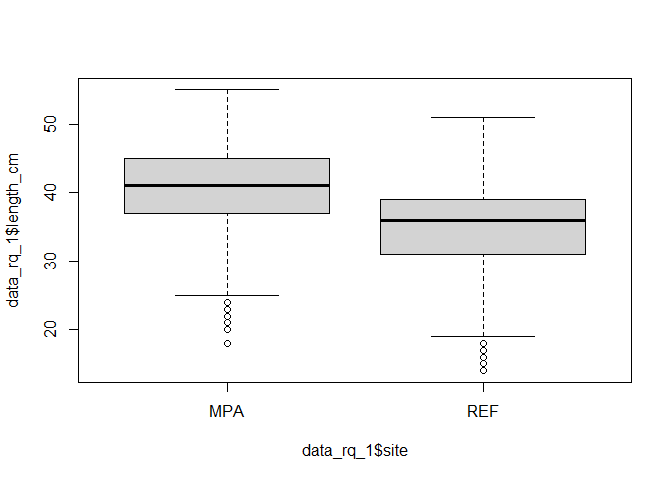

```r
## equal variance

boxplot(data_rq_1$length_cm ~ data_rq_1$site)
```

```r
bartlett.test(length_cm ~ site, data = data_rq_1)
```

```
##
##  Bartlett test of homogeneity of variances
##
## data:  length_cm by site
## Bartlett's K-squared = 14.081, df = 1, p-value = 0.0001751
```

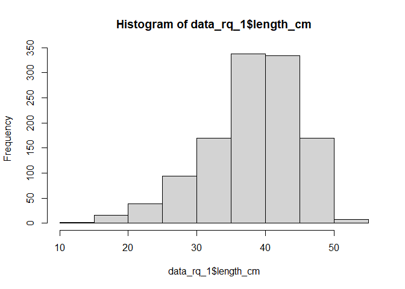

```r
## doesn't have equal variance

## normality

hist(data_rq_1$length_cm)
```

```r
shapiro.test(data_rq_1$length_cm)
```

```
##
##  Shapiro-Wilk normality test
##
## data:  data_rq_1$length_cm
## W = 0.96244, p-value < 2.2e-16
```

```r
## hmm not normal


## independence

## no good way to check this... but if you used a randomized sampling design (which we did!) you can assume a good amount of independence
```

It looks like there is a difference between the length of Vermilion Rockfish in the MPA and the REF site… is it statistically different? Let’s find out.

## T-Test Hypothesis Testing

Null hypothesis or H<sub>0</sub> : There is NO difference in length of Vermilion Rockfish between the MPA and the REF site. Another way to say this: the true difference in means between MPA and REF is 0.

Alternative hypothesis or H<sub>a</sub>: There is a difference in length of Vermilion Rockfish between the MPA and the REF site. Another way to say this: the true difference in means between MPA and REF is not 0.

**REMEMBER** a small p-value will indicate more evidence in favor of the alternative hypothesis (we reject the null hypothesis), which means there is a difference, while a large p-value will indicate that we don’t have enough evidence to reject the null hypothesis, which means there is no statistical difference that we can prove with our data.

```r
t_test_length <- t.test(length_cm ~ site, data = data_rq_1)

t_test_length
```

```
##
##  Welch Two Sample t-test
##
## data:  length_cm by site
## t = 12.133, df = 455.54, p-value < 2.2e-16
## alternative hypothesis: true difference in means between group MPA and group REF is not equal to 0
## 95 percent confidence interval:
##  4.689969 6.502855
## sample estimates:
## mean in group MPA mean in group REF
##          40.10472          34.50831
```

```r
## anoter way to check for normality
# qqnorm(data_rq_1$length_cm)
# qqline(data_rq_1$length_cm)
```

> Conclusion: We have enough evidence to reject the null hypothesis and conclude that there is a difference in mean length of Vermilion Rockfish between the Point Buchon MPA and REF sites.

## Visualization T-Test

Now let’s practice making a better looking visual

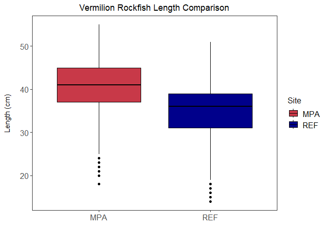

```r
# data_rq_1_plot <- data_rq_1 %>%
#   group_by(site) %>%
#   mutate(se = std.error(length_cm))

ggplot(data = data_rq_1) +
  geom_boxplot(aes(x = site, y = length_cm, fill = site), color = "black")+
  scale_fill_manual(name = "Site", values = c( "#C83948", "darkblue"))+
  labs(x = "", y = "Length (cm)\n", title = "Vermilion Rockfish Length Comparison")+
  theme_bw() +
  theme(panel.grid = element_blank(),
        plot.title = element_text(hjust = 0.5),
        axis.text = element_text(size = 12),
        legend.text = element_text(size = 12),
        legend.title = element_text(size = 12))
```

# ANOVA TIME

[figure not shown]

Looking at the flowchart for Research Question 2:

- Is the predictor variable categorical or quantitative?
- Is the response variable categorical or quantitative?
- How many groups are being compared?
- What kind of test should we use?

  > ANOVA

*Are fish length different in MPAs from San Diego to Humboldt for Vermilion Rockfish?*

```r
data_rq_2 <- raw_dat_str %>%
  filter(species == "VER",
         !year == 2023,
         site == "MPA") %>%
  select(area, site, year, species, length_cm)
```

## Investigation & Assumption Checking

Let’s do a quick investigative visual and check our assumptions before we continue with the stats

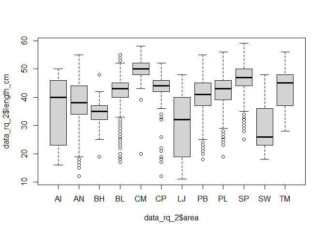

```r
## equal variance

boxplot(data_rq_2$length_cm ~ data_rq_2$area)
```

```r
bartlett.test(length_cm ~ area, data = data_rq_2) ## doesn't have equal variance
```

```
##
##  Bartlett test of homogeneity of variances
##
## data:  length_cm by area
## Bartlett's K-squared = 288.29, df = 11, p-value < 2.2e-16
```

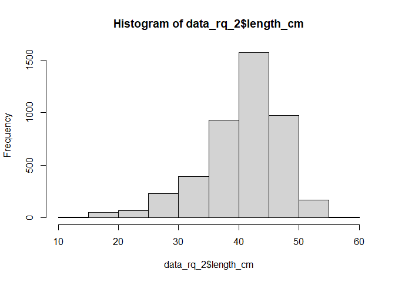

```r
## normality

hist(data_rq_2$length_cm)
```

```r
shapiro.test(data_rq_2$length_cm) ## hmm not normal
```

```
##
##  Shapiro-Wilk normality test
##
## data:  data_rq_2$length_cm
## W = 0.94475, p-value < 2.2e-16
```

```r
## independence

## no good way to check this... but if you used a randomized sampling design (which we did!) you can assume a good amount of independence
```

> “In general, a one-way ANOVA is considered to be fairly robust against violations of the normality [and equal variance] assumption as long as the sample sizes are sufficiently large.”

A little messier, but it looks like there are some differences visually AT LEAST between some groups

## ANOVA Hypothesis Testing

Null hypothesis or H<sub>0</sub> : There are NO difference in length of Vermilion Rockfish between any of the areas. Another way to say this: the true difference in means between all the areas is 0.

```r
anova_model <- aov(length_cm ~ area, data = data_rq_2)

summary(anova_model)
```

```
##               Df Sum Sq Mean Sq F value Pr(>F)
## area          11  38859    3533   96.12 <2e-16 ***
## Residuals   4392 161410      37
## ---
## Signif. codes:  0 '***' 0.001 '**' 0.01 '*' 0.05 '.' 0.1 ' ' 1
## 8 observations deleted due to missingness
```

```r
#plot(anova_model, 2) ## another check for normality after model is made
```

> Conclusion: We have enough evidence to reject the null hypothesis and conclude that there is a difference in mean length of Vermilion Rockfish in at least one area.

Okay there is at least one area with a difference in Vermilion Rockfish Length… but where is the difference?

## Post Hoc Testing

```r
post_hoc_test <- TukeyHSD(anova_model)

post_hoc_test
```

```
##   Tukey multiple comparisons of means
##     95% family-wise confidence level
##
## Fit: aov(formula = length_cm ~ area, data = data_rq_2)
##
## $area
##                diff         lwr         upr     p adj
## AN-AI   2.474611399  -3.8341961   8.7834189 0.9813535
## BH-AI  -1.713580247  -8.3575973   4.9304368 0.9995322
## BL-AI   6.067127496  -0.2252385  12.3594935 0.0709657
## CM-AI  13.562745098   6.9943166  20.1311736 0.0000000
## CP-AI   7.416867470   1.0238961  13.8098389 0.0083013
## LJ-AI  -6.292537313 -13.0124018   0.4273271 0.0918674
## PB-AI   4.304718067  -1.9995853  10.6090214 0.5256696
## PL-AI   6.032451499  -0.2909234  12.3558264 0.0781366
## SP-AI  10.371779141   4.0080250  16.7355333 0.0000068
## SW-AI  -6.300000000 -16.5361565   3.9361565 0.6850318
## TM-AI   7.350943396   0.5167873  14.1850995 0.0224068
## BH-AN  -4.188191646  -6.5033244  -1.8730588 0.0000003
## BL-AN   3.592516097   2.6921010   4.4929312 0.0000000
## CM-AN  11.088133699   8.9998018  13.1764656 0.0000000
## CP-AN   4.942256071   3.4976245   6.3868876 0.0000000
## LJ-AN  -8.767148712 -11.2917191  -6.2425783 0.0000000
## PB-AN   1.830106668   0.8497405   2.8104728 0.0000001
## PL-AN   3.557840100   2.4615067   4.6541735 0.0000000
## SP-AN   7.897167742   6.5878765   9.2064590 0.0000000
## SW-AN  -8.774611399 -16.8983899  -0.6508329 0.0213070
## TM-AN   4.876331997   2.0616266   7.6910374 0.0000011
## BL-BH   7.780707743   5.5107611  10.0506543 0.0000000
## CM-BH  15.276325345  12.3262337  18.2264169 0.0000000
## CP-BH   9.130447717   6.5949260  11.6659695 0.0000000
## LJ-BH  -4.578957067  -7.8523904  -1.3055237 0.0003071
## PB-BH   6.018298314   3.7154679   8.3211287 0.0000000
## PL-BH   7.746031746   5.3914921  10.1005714 0.0000000
## SP-BH  12.085359388   9.6244340  14.5462848 0.0000000
## SW-BH  -4.586419753 -12.9731764   3.8003369 0.8247987
## TM-BH   9.064523643   5.5624562  12.5665911 0.0000000
## CM-BL   7.495617602   5.4574940   9.5337412 0.0000000
## CP-BL   1.349739974  -0.0213100   2.7207899 0.0583517
## LJ-BL -12.359664810 -14.8428630  -9.8764666 0.0000000
```

[output cut: 18 more lines]

```
## PB-LJ  10.597255380   8.0839620  13.1105488 0.0000000
## PL-LJ  12.324988813   9.7642325  14.8857451 0.0000000
## SP-LJ  16.664316455  14.0054126  19.3232203 0.0000000
## SW-LJ  -0.007462687  -8.4544328   8.4395074 1.0000000
## TM-LJ  13.643480710   9.9995691  17.2873924 0.0000000
## PL-PB   1.727733432   0.6576236   2.7978433 0.0000089
## SP-PB   6.067061074   4.7796483   7.3544739 0.0000000
## SW-PB -10.604718067 -18.7249992  -2.4844369 0.0012030
## TM-PB   3.046225329   0.2416301   5.8508205 0.0199052
## SP-PL   4.339327642   2.9615537   5.7171015 0.0000000
## SW-PL -12.332451499 -20.4675480  -4.1973550 0.0000477
## TM-PL   1.318491897  -1.5287144   4.1656982 0.9370281
## SW-SP -16.671779141 -24.8383017  -8.5052565 0.0000000
## TM-SP  -3.020835745  -5.9566287  -0.0850428 0.0371305
## TM-SW  13.650943396   5.1127695  22.1891173 0.0000117
```

## Visualization ANOVA

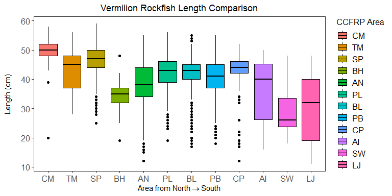

```r
data_rq_2$area <- factor(data_rq_2$area, levels=c("CM", "TM", "SP", "BH", "AN", "PL", "BL", "PB", "CP", "AI", "SW","LJ"))

ggplot(data = data_rq_2) +
  geom_boxplot(aes(x = area, y = length_cm, fill = area), color = "black")+
  labs(x = expression("Area from North" %->%South), y = "Length (cm)\n", title = "Vermilion Rockfish Length Comparison")+
  theme_bw() +
  theme(panel.grid = element_blank(),
        plot.title = element_text(hjust = 0.5),
        axis.text = element_text(size = 12),
        legend.text = element_text(size = 12),
        legend.title = element_text(size = 12))+
  guides(fill=guide_legend(title="CCFRP Area"))
```